# Homework 6: GLM and LM, prediction

Nicole Carlson.

## Homework 6

### Background and Information on HELP Dataset

For homework 6, you will be working with the **HELP** (Health Evaluation and Linkage to Primary Care) Dataset.

The HELP Dataset:

- You can learn more about the HELP (Health Evaluation and Linkage to Primary Care) dataset at https://nhorton.people.amherst.edu/sasr2/datasets.php. This dataset is also used by Ken Kleinman and Nicholas J. Horton for their book “SAS and R: Data Management, Statistical Analysis, and Graphics” (which is another helpful textbook).
- You can download the datasets from their website https://nhorton.people.amherst.edu/sasr2/datasets.php
- The original publication is referenced at https://www.ncbi.nlm.nih.gov/pubmed/12653820?ordinalpos=17&itool=EntrezSystem2.PEntrez.Pubmed.Pubmed_ResultsPanel.Pubmed_DefaultReportPanel.Pubmed_RVDocSum
- The HELP documentation (including all forms/surveys/instruments used) are located at:
  - https://nhorton.people.amherst.edu/help/
  - specifically the details on all BASELINE assessments are located in this PDF https://nhorton.people.amherst.edu/help/HELP-baseline.pdf
  - with the follow up time points described in the PDF https://nhorton.people.amherst.edu/help/HELP-followup.pdf

### Summary of Entire HELP Dataset - Complete Codebook

See complete data descriptions and codebook at https://melindahiggins2000.github.io/N736Fall2017_HELPdataset/

### Variables for Homework 6

For Homework 6, you will focus only on these variables from the HELP dataset:

Use these variables from HELP dataset for Homework 06

|  | Variable Label |
| --- | --- |
| age | Age at baseline (in years) |
| female | Gender of respondent |
| pss_fr | Perceived Social Support - friends |
| homeless | One or more nights on the street or shelter in past 6 months |
| pcs | SF36 Physical Composite Score - Baseline |
| mcs | SF36 Mental Composite Score - Baseline |
| cesd | CESD total score - Baseline |

## Homework 6 Assignment

**SETUP** Download and run the “loadHELP.R” `R` script (included in this Github repo https://github.com/melindahiggins2000/N741Spring2018_Homework6) to read in the HELP Dataset “helpmkh.sav”. This script also pulls out the variables you need and creates the dichotomous variable for depression `cesd_gte16` which you will need for the logistic regression.

After running this R script, you will have a data frame called `h1` you can use to do the rest of your analyses. You can also copy this code into your first R markdown code chunk to get you started on Homework 6.

For Homework 6, you will be looking at depression in these subjects. First, you will be running a model to look at the continuous depression measure - the CESD [Center for Epidemiologic Studies Depression Scale](http://cesd-r.com/) which is a measure of depressive symptoms. Also see the APA details on the CESD at http://www.apa.org/pi/about/publications/caregivers/practice-settings/assessment/tools/depression-scale.aspx. The CESD can be used to predict actual clinical depression but it is not technically a diagnosis of depression. The CESD scores range from 0 (no depressive symptoms) to 60 (most severe depressive symptoms). You will use the (`cesd`) variable to run a linear regression.

The recommended threshold use to indicate potential clinical depression is for people with scores of 16 or greater. You will then use the variable created using this cutoff (`cesd_gte16`) to perform a similar modeling approach with the variables to predict the probability of clinical depression (using logistic regression).

## Homework 6 Tasks

1. [Model 1] Run a simple linear regression (`lm()`) for `cesd` using the `mcs` variable, which is the mental component quality of life score from the SF36.

```r
library(car)
library(stargazer)
h1 <- readRDS("h1.rds")
unajustedCESD <- lm(cesd ~ mcs, data = h1)
summary(unajustedCESD)
```

```
##
## Call:
## lm(formula = cesd ~ mcs, data = h1)
##
## Residuals:
##      Min       1Q   Median       3Q      Max
## -27.3593  -6.7277  -0.0024   6.2374  24.4239
##
## Coefficients:
##             Estimate Std. Error t value Pr(>|t|)
## (Intercept) 53.90219    1.14723   46.98   <2e-16 ***
## mcs         -0.66467    0.03357  -19.80   <2e-16 ***
## ---
## Signif. codes:  0 '***' 0.001 '**' 0.01 '*' 0.05 '.' 0.1 ' ' 1
##
## Residual standard error: 9.164 on 451 degrees of freedom
## Multiple R-squared:  0.465,  Adjusted R-squared:  0.4638
## F-statistic:   392 on 1 and 451 DF,  p-value: < 2.2e-16
```

2. Write the equation of the final fitted model (i.e. what is the intercept and the slope)? Write a sentence describing the model results (interpret the intercept and slope). *NOTE: The `mcs` values range form 0 to 100 where the population norm for “normal mental health quality of life” is considered to be a 50. If you score higher than 50 on the `mcs` you have mental health better than the population and visa versa - if your `mcs` scores are less than 50 then your mental health is considered to be worse than the population norm.*

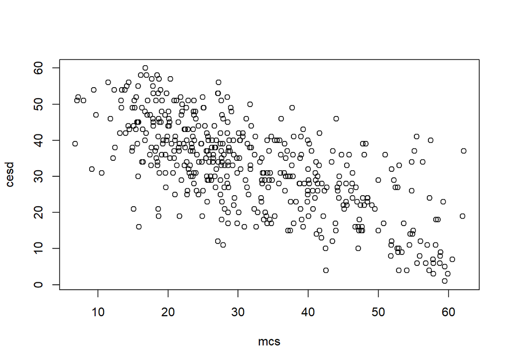

```r
plot(cesd ~ mcs, data = h1)
```

Equation for final fitted model: cesd= 53.90 - 0.66 (msc)

Interpretation: The mean cesd score is 53.90 when mcs score is equal to 0. For each increase in mcs of 1 point, the cesd score decreases by 0.66 points. You can see from the plot above that there is a linear relationship beteween these two variables, and most of the cases in this dataset have mcs scores below the ‘normal’ level of 50.

3. How much variability in the `cesd` does the `mcs` explain? (what is the R<sup>2</sup>?) Write a sentence describing how well the `mcs` does in predicting the `cesd`.

MCS score explains 46% of the variability in the CESD score.

4. [Model 2] Run a second linear regression model (`lm()`) for the `cesd` putting in all of the other variables:
   - `age`
   - `female`
   - `pss_fr`
   - `homeless`
   - `pcs`
   - `mcs`
   - Print out the model results with the coefficients and tests and model fit statistics.

```r
ajustedCESD <- lm(cesd ~ ., data = h1)
summary(ajustedCESD)
```

```
##
## Call:
## lm(formula = cesd ~ ., data = h1)
##
## Residuals:
##      Min       1Q   Median       3Q      Max
## -24.2355  -4.8786   0.3747   4.7882  20.0050
##
## Coefficients:
##             Estimate Std. Error t value Pr(>|t|)
## (Intercept) 43.31517    3.66021  11.834  < 2e-16 ***
## age          0.01319    0.05001   0.264  0.79203
## female       2.78914    0.89816   3.105  0.00202 **
## pss_fr      -0.20686    0.09606  -2.153  0.03182 *
## homeless     0.53040    0.76499   0.693  0.48846
## pcs         -0.18016    0.03665  -4.916 1.24e-06 ***
## mcs         -0.45830    0.03393 -13.506  < 2e-16 ***
## cesd_gte16  14.15701    1.44383   9.805  < 2e-16 ***
## ---
## Signif. codes:  0 '***' 0.001 '**' 0.01 '*' 0.05 '.' 0.1 ' ' 1
##
## Residual standard error: 7.883 on 445 degrees of freedom
## Multiple R-squared:  0.6093, Adjusted R-squared:  0.6032
## F-statistic: 99.15 on 7 and 445 DF,  p-value: < 2.2e-16
```

5. Which variables are significant in the model? Write a sentence or two describing the impact of these variables for predicting depression scores (HINT: interpret the coefficient terms).

In this adjusted model of cesd, the significant predictors were: female gender, pss_fr, pcs, mcs, and cesd_gte16.

6. Following the example we did in class for the Prestige dataset https://cdn.rawgit.com/vhertzb/2018week9/2f2ea142/2018week9.html?raw=true, generate the diagnostic plotss for this model with these 6 predictors (e.g. get the residual plot by variables, the added-variable plots, the Q-Q plot, diagnostic plots). Also run the VIFs to check for multicollinearity issues.

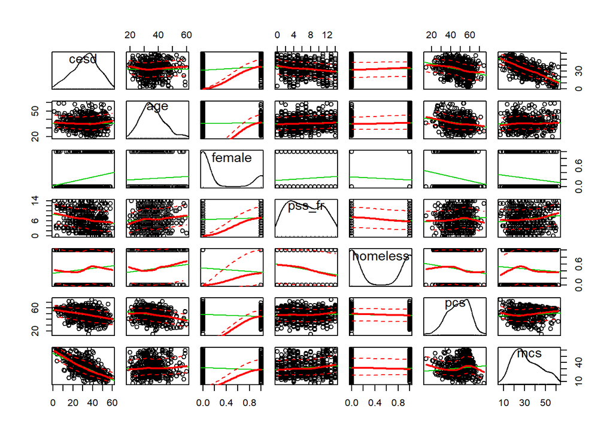

```r
scatterplotMatrix(~ cesd + age + female + pss_fr + + homeless + pcs + mcs, span =0.7, data = h1)
```

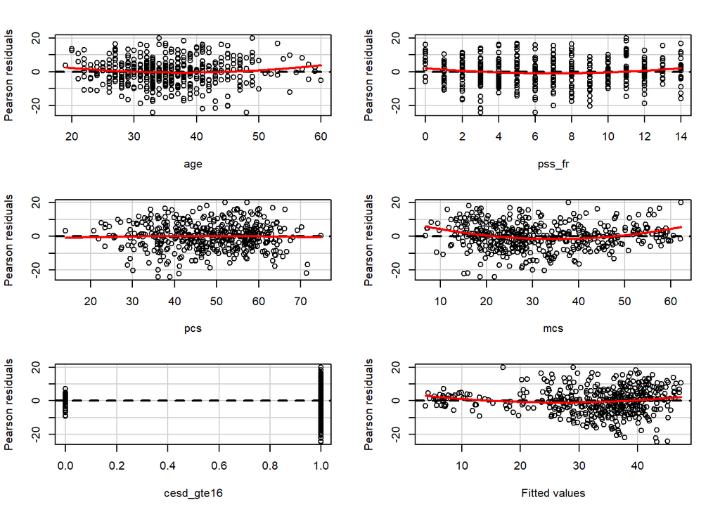

```
##            Test stat Pr(>|t|)
## age            1.954    0.051
## pss_fr         2.511    0.012
## pcs           -0.391    0.696
## mcs            4.984    0.000
## cesd_gte16    -1.504    0.133
## Tukey test     4.100    0.000
```

```r
residualPlots(ajustedCESD)
```

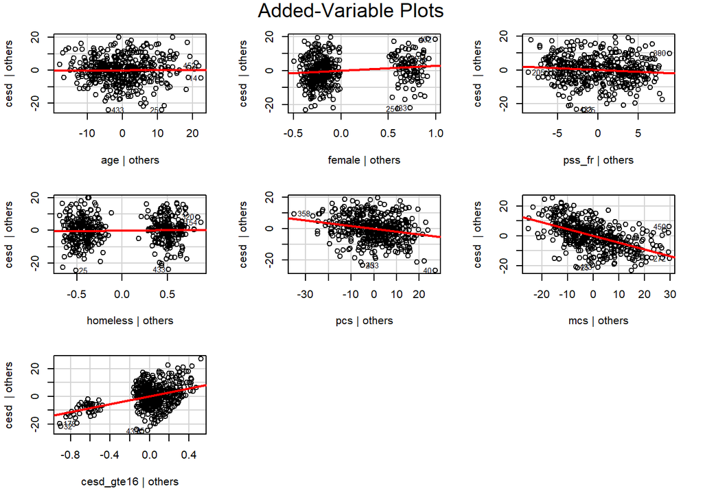

```r
avPlots(ajustedCESD, id.n=2, id.cex=0.7)
```

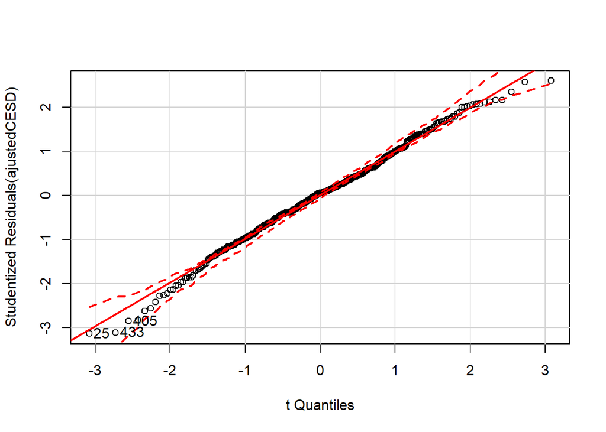

```
##  25 433 405
##   1   2   3
```

```r
qqPlot(ajustedCESD, id.n=3)
```

```r
outlierTest(ajustedCESD)
```

```
##
## No Studentized residuals with Bonferonni p < 0.05
## Largest |rstudent|:
##     rstudent unadjusted p-value Bonferonni p
## 25 -3.133781            0.00184      0.83354
```

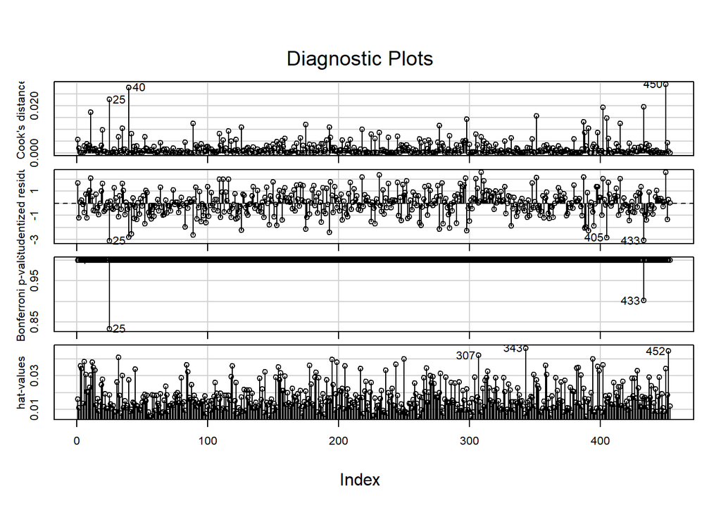

```r
influenceIndexPlot(ajustedCESD, id.n=3)
```

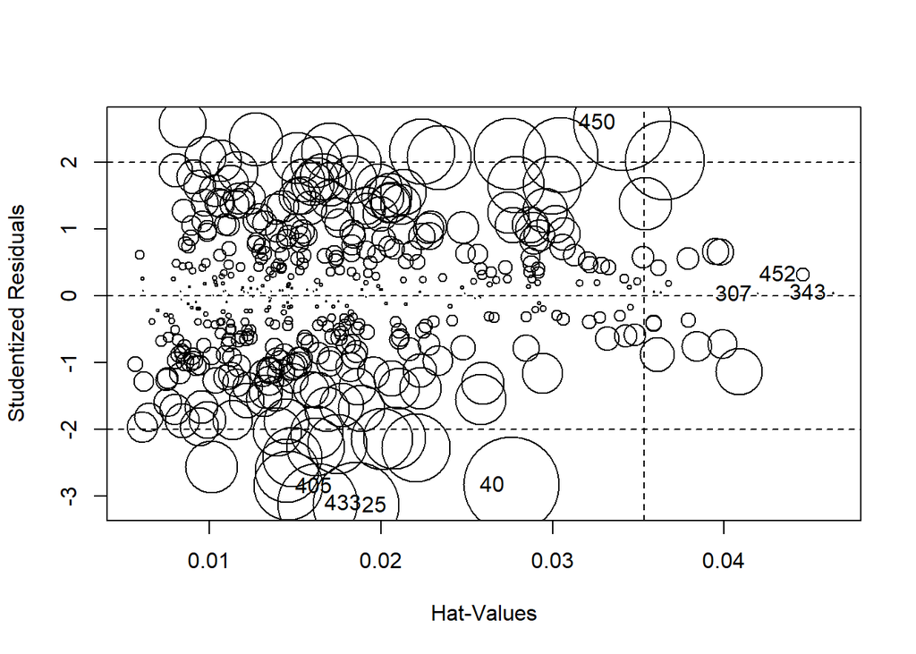

```
##         StudRes        Hat        CookD
## 25  -3.13378120 0.01852040 2.271392e-02
## 40  -2.82863028 0.02758366 2.793075e-02
## 307  0.02864576 0.04198018 4.504813e-06
## 343  0.04345031 0.04633582 1.149192e-05
## 405 -2.84590477 0.01460759 1.477224e-02
## 433 -3.11008039 0.01631893 1.967470e-02
## 450  2.59355446 0.03406544 2.927615e-02
## 452  0.31723229 0.04458614 5.882362e-04
```

```r
influencePlot(ajustedCESD, id.n=3)
```

```r
ncvTest(ajustedCESD)
```

```
## Non-constant Variance Score Test
## Variance formula: ~ fitted.values
## Chisquare = 13.47059    Df = 1     p = 0.0002423324
```

```r
vif(ajustedCESD)
```

```
##        age     female     pss_fr   homeless        pcs        mcs
##   1.081464   1.060867   1.071092   1.060086   1.135996   1.380623
## cesd_gte16
##   1.386363
```

7. [Model 3] Repeat Model 1 above, except this time run a logistic regression (`glm()`) to predict CESD scores => 16 (using the `cesd_gte16` as the outcome) as a function of `mcs` scores. Show a summary of the final fitted model and explain the coefficients. [**REMEMBER** to compute the Odds Ratios after you get the raw coefficient (betas)].

```r
logisticCESD <- glm(cesd_gte16 ~ mcs, data = h1)
summary(logisticCESD)
```

```
##
## Call:
## glm(formula = cesd_gte16 ~ mcs, data = h1)
##
## Deviance Residuals:
##      Min        1Q    Median        3Q       Max
## -0.95274  -0.05516   0.03689   0.15255   0.46512
##
## Coefficients:
##               Estimate Std. Error t value Pr(>|t|)
## (Intercept)  1.2760656  0.0326857   39.04   <2e-16 ***
## mcs         -0.0119208  0.0009564  -12.46   <2e-16 ***
## ---
## Signif. codes:  0 '***' 0.001 '**' 0.01 '*' 0.05 '.' 0.1 ' ' 1
##
## (Dispersion parameter for gaussian family taken to be 0.06816063)
##
##     Null deviance: 41.329  on 452  degrees of freedom
## Residual deviance: 30.740  on 451  degrees of freedom
## AIC: 72.847
##
## Number of Fisher Scoring iterations: 2
```

```r
exp(cbind(OR = coef(logisticCESD), confint(logisticCESD)))
```

```
##                   OR     2.5 %    97.5 %
## (Intercept) 3.582517 3.3602081 3.8195336
## mcs         0.988150 0.9862994 0.9900041
```

8. Use the `predict()` function like we did in class to predict CESD => 16 and compare it back to the original data. For now, use a cutoff probability of 0.5 - if the probability is > 0.5 consider this to be true and false otherwise. Like we did in class. **REMEMBER** See the R code for the class example at https://github.com/melindahiggins2000/N741_lecture11_27March2018/blob/master/lesson11_logreg_Rcode.R
   - How well did the model correctly predict CESD scores => 16 (indicating depression)? (make the “confusion matrix” and look at the true positives and true negatives versus the false positives and false negatives).

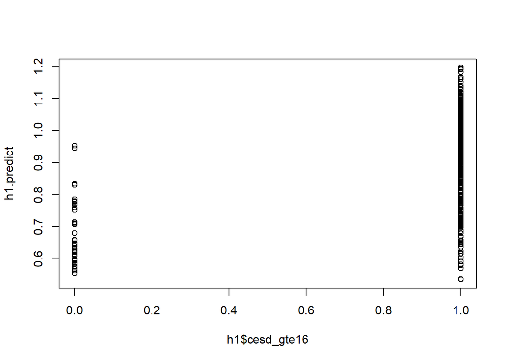

```r
h1.predict <- predict(logisticCESD, newdata=h1,
                      type="response")
plot(h1$cesd_gte16, h1.predict)
```

```r
table(h1$cesd_gte16, h1.predict > 0.5)
```

```
##
##     TRUE
##   0   46
##   1  407
```

9. Make an ROC curve plot and compute the AUC and explain if this is a good model for predicting depression or not

```r
library(ROCR)
```

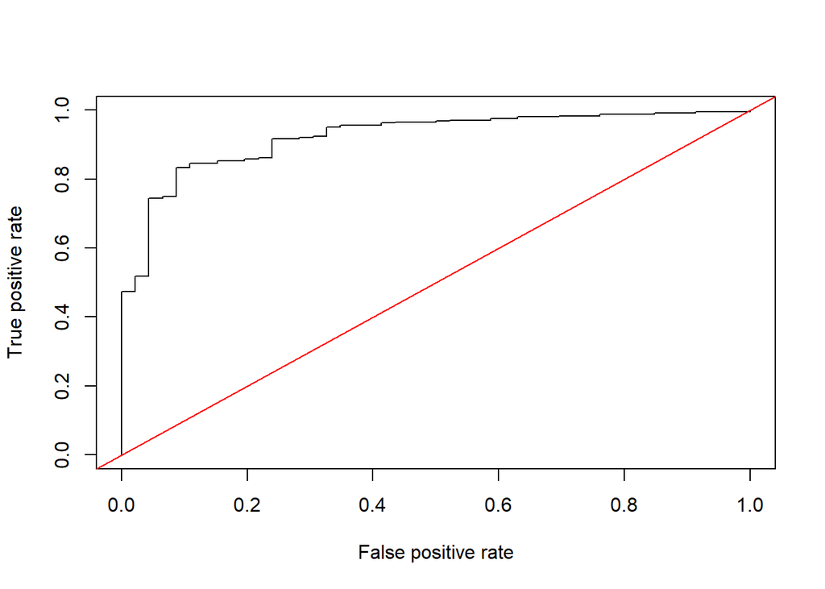

```r
p <- predict(logisticCESD, newdata=h1,
             type="response")
pr <- prediction(p, as.numeric(h1$cesd_gte16))
prf <- performance(pr, measure = "tpr", x.measure = "fpr")
plot(prf)
abline(a=0, b=1, col="red")
```

```r
auc <- performance(pr, measure = "auc")
auc <- auc@y.values[[1]]
auc
```

```
## [1] 0.9221771
```

10. Make a plot showing the probability curve - put the `mcs` values on the X-axis and the probability of depression on the Y-axis. Based on this plot, do you think the `mcs` is a good predictor of depression? [**FYI** This plot is also called an “effect plot” is you’re using `Rcmdr` to do these analyses.]

```r
library(Rcmdr)
```

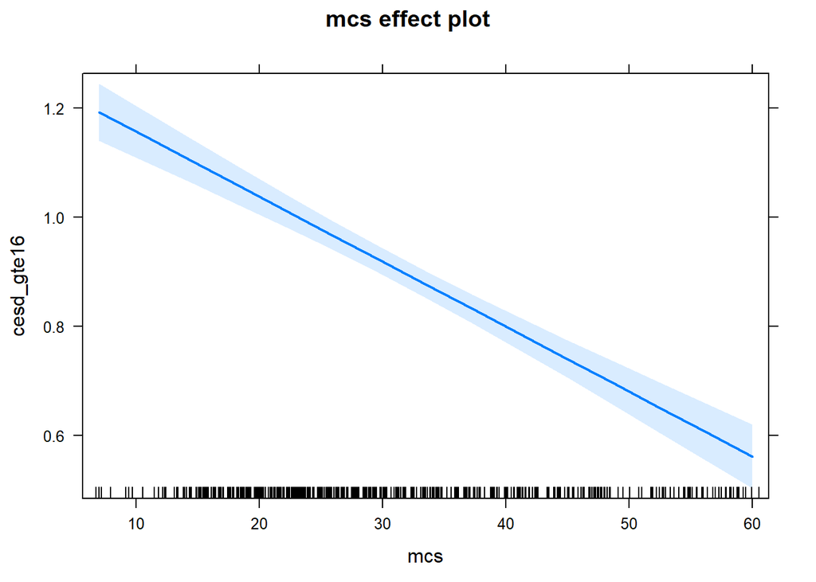

```r
plot(allEffects(logisticCESD))
```

**Use R markdown to complete your homework and show all of your code and output in your final report - Turn in a PDF of your report to Canvas. Include a link to your Github repo for Homework 6**